# Rを用いた因果効果算出方法の確認

Kazuhisa Ishihara

2022年2月12日

## 目的

岩波データサイエンス Vol.3を買ったので「CM接触の因果効果と調整効果」におけるデータおよび結果をテキストにRを用いた因果効果推定方法を学習する。 正解というか、お手本は著者（加藤 諒＆星野 崇宏）により  
https://github.com/iwanami-datascience/vol3/tree/master/kato%26hoshino  
にRコードとデータが公開されている。また、  
https://tjo.hatenablog.com/entry/2016/08/29/190000#fn-aebe1af1  
などでも解説されている。

## データの読み込みと説明

マーケットリサーチのための有償のパネルボランティアより得た情報に基づくデータ。 ゲームに対するCM効果を推定するために供給されたものらしい。 有償パネルで1万レコードって・・・と思ったら疑似データと書いてあった。  
カテゴリ変数はすべてダミー変数化されている。  
CMへの接触の有無、ゲームプレイの有無・回数・秒数、TVの視聴秒数といった行動履歴から、年齢・性別などのデモグラフィック、家族構成・居住地・所得・学歴などソシオグラフィックがデータ化されていると書かれている。 学歴、出てきてないけど  
・・・こういうのソシオグラフィック(sociographics)っていうのね。確かに人のメタ情報としてはdemographicsとはちょっと違うか。  
ぶっちゃけ、あまりきちんと変数について説明がされておらず、ちょっとこの事例を使うことを後悔している。  
・・・が、練習としてはどうでもいいか。

```r
#データの読み込み　公開データをRで直接読み込む。
data1 <- read.csv("https://github.com/iwanami-datascience/vol3/raw/master/kato%26hoshino/q_data_x.csv")
names(data1)
```

```
##  [1] "cm_dummy"        "gamedummy"       "area_kanto"      "area_keihan"
##  [5] "area_tokai"      "area_keihanshin" "age"             "sex"
##  [9] "marry_dummy"     "job_dummy1"      "job_dummy2"      "job_dummy3"
## [13] "job_dummy4"      "job_dummy5"      "job_dummy6"      "job_dummy7"
## [17] "job_dummy8"      "inc"             "pmoney"          "fam_str_dummy1"
## [21] "fam_str_dummy2"  "fam_str_dummy3"  "fam_str_dummy4"  "fam_str_dummy5"
## [25] "child_dummy"     "T"               "F1"              "F2"
## [29] "F3"              "M1"              "M2"              "M3"
## [33] "TVwatch_day"     "gamesecond"      "gamecount"
```

cm_dummy;CMを見たか否か 1が見た場合  
gamedummy;ゲームアプリの利用者か否か おそらく1が実施  
area ;居住エリア おそらくいずれも居住地の場合1  
_kanto  
_keihan  
_tokai  
_keihanshin  
age ;被験者年齢 連続値  
sex ;性別 男性1 女性0  
marry_dummy ;婚姻状況 おそらく1が既婚  
job_dummy1 - job_dummy8 ;被験者の職業 8種あるけど、なにかわからん!  
inc ;年収 連続値 0は扶養家族かな～ ホントはhouse incomeにしないとダメなような。  
pmoney ;月当たりのお小遣いらしい 連続値  
fam_str_dummy1 - fam_str_dummy5 ;家族構成 なにかわからん!  
child_dummy ;子供の有無 おそらく1が有り

以下は広告業界でよく使われる分類だそうな  
T ;T層 13-19歳の男女  
F1 ;20-34歳の女性  
F2 ;35-49歳の女性  
F3 ;50歳以上の女性  
M1 ;20-34歳の男性  
M2 ;35-49歳の男性  
M3 ;50歳以上の男性

TVwatch_day ;1日あたりの平均テレビ視聴時間  
gamesecond ;ゲーム実施時間  
gamecount ;ゲーム実施回数

## ロジスティクス回帰によるPSスコアの算出

お手本をなぞって変数を投入 選択理由は気にしない

```r
#formulaの作成
covname <- names(data1)
psfm <- paste(covname[c(33, 7:9, 25, 18:19, 3, 5:6, 10:16, 20:23)],
                collapse = "+") %>%
        paste("cm_dummy ~ ", .) %>%
        formula()
psfm
```

```
## cm_dummy ~ TVwatch_day + age + sex + marry_dummy + child_dummy +
##     inc + pmoney + area_kanto + area_tokai + area_keihanshin +
##     job_dummy1 + job_dummy2 + job_dummy3 + job_dummy4 + job_dummy5 +
##     job_dummy6 + job_dummy7 + fam_str_dummy1 + fam_str_dummy2 +
##     fam_str_dummy3 + fam_str_dummy4
## <environment: 0x000000001c292a50>
```

```r
#PSスコアの算出
fm1 <- glm(psfm, data = data1, family = binomial(link = "logit"))
summary(fm1)
```

```
##
## Call:
## glm(formula = psfm, family = binomial(link = "logit"), data = data1)
##
## Deviance Residuals:
##     Min       1Q   Median       3Q      Max
## -3.0042  -0.8925  -0.4197   0.9969   2.4274
##
## Coefficients:
##                   Estimate Std. Error z value Pr(>|z|)
## (Intercept)     -1.771e+00  2.615e-01  -6.773 1.26e-11 ***
## TVwatch_day      1.322e-04  4.131e-06  31.996  < 2e-16 ***
## age             -2.606e-03  2.937e-03  -0.887 0.374975
## sex              5.951e-04  6.467e-02   0.009 0.992657
## marry_dummy     -7.815e-02  8.556e-02  -0.913 0.361021
## child_dummy      3.142e-01  7.433e-02   4.227 2.37e-05 ***
## inc             -4.890e-04  1.675e-04  -2.919 0.003510 **
## pmoney           1.192e-02  7.721e-03   1.543 0.122710
## area_kanto       4.050e-01  7.904e-02   5.124 2.99e-07 ***
## area_tokai      -7.233e-01  7.654e-02  -9.449  < 2e-16 ***
## area_keihanshin -2.042e+00  7.560e-02 -27.012  < 2e-16 ***
## job_dummy1       1.752e-01  1.562e-01   1.122 0.261895
## job_dummy2       1.651e-01  1.677e-01   0.984 0.324984
## job_dummy3       5.399e-01  1.604e-01   3.366 0.000763 ***
## job_dummy4       3.604e-01  2.433e-01   1.481 0.138579
## job_dummy5       6.414e-01  1.520e-01   4.220 2.45e-05 ***
## job_dummy6       2.848e-01  1.581e-01   1.801 0.071689 .
## job_dummy7       1.540e-01  1.834e-01   0.839 0.401238
## fam_str_dummy1   7.640e-01  2.045e-01   3.736 0.000187 ***
## fam_str_dummy2   1.003e+00  2.175e-01   4.612 3.99e-06 ***
## fam_str_dummy3   6.137e-01  2.021e-01   3.037 0.002386 **
## fam_str_dummy4   1.799e-01  2.216e-01   0.812 0.416695
## ---
## Signif. codes:  0 '***' 0.001 '**' 0.01 '*' 0.05 '.' 0.1 ' ' 1
##
## (Dispersion parameter for binomial family taken to be 1)
##
##     Null deviance: 13568  on 9999  degrees of freedom
## Residual deviance: 10842  on 9978  degrees of freedom
## AIC: 10886
##
## Number of Fisher Scoring iterations: 4
```

```r
data1$PScore <- fm1$fitted.values

#ROC曲線を書いておく 古い人間なので、plotが一番楽なのさ
ROC1 <- roc(cm_dummy ~ PScore, data = data1, ci = TRUE)
ROC1
```

```
##
## Call:
## roc.formula(formula = cm_dummy ~ PScore, data = data1, ci = TRUE)
##
## Data: PScore in 5856 controls (cm_dummy 0) < 4144 cases (cm_dummy 1).
## Area under the curve: 0.7917
## 95% CI: 0.7829-0.8005 (DeLong)
```

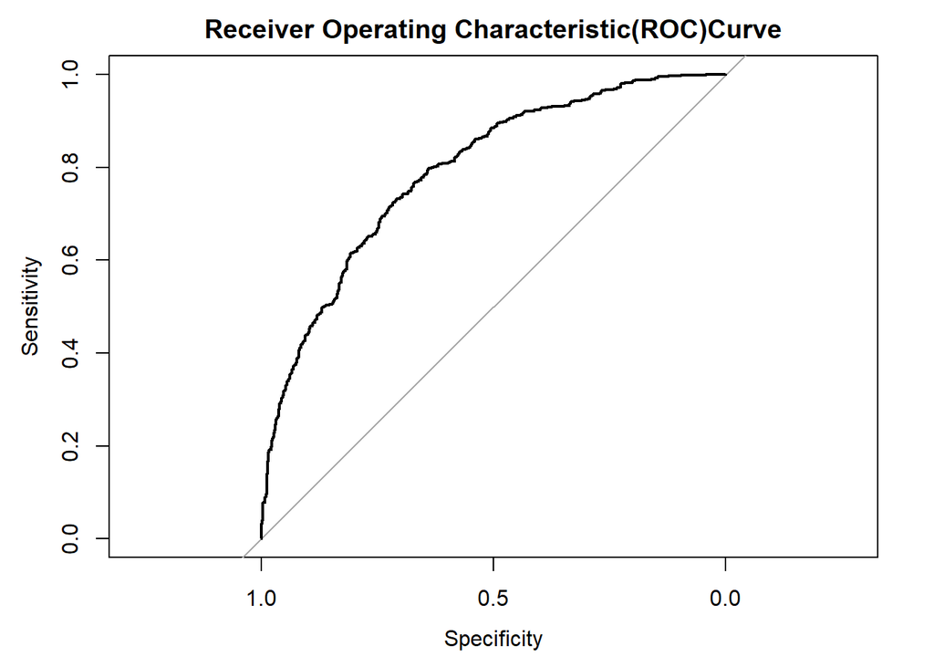

```r
plot (ROC1, main = "Receiver Operating Characteristic(ROC)Curve")
```

c統計量は0.791とお手本通りの結果。ROC曲線もきれいだな。

# IPWの確認

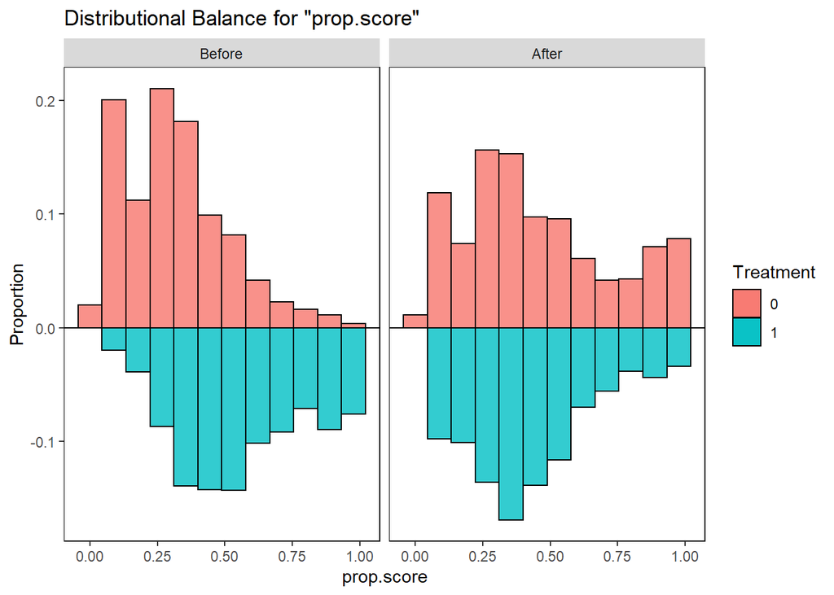

```r
#ここではRパッケージのweightitで重みを計算してみる
IPW_weight <- weightit(
        psfm,
        data = data1,
        method = "ps",
        ps = data1$PScore,
        estimand = "ATE",
        stabilize = FALSE
        )

#データセットに対するweightの付加
data1 <- mutate(data1, IPW = IPW_weight$weights)

#PSスコアのバランス確認　これもRパッケージのcobaltで実施
bal.plot(IPW_weight, var.name = "prop.score", which = "both",
          type = "histogram", mirror = TRUE,
          sample.names = c("Before", "After"))
```

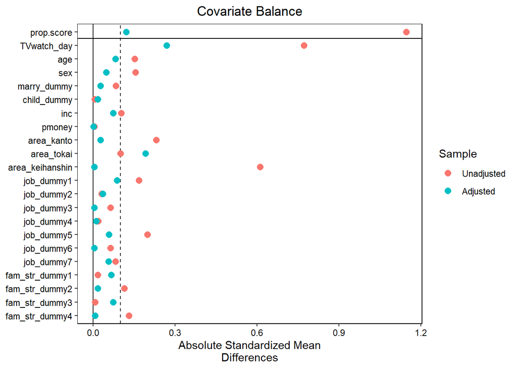

```r
#共変量のバランス確認
set.cobalt.options(binary = "std") #標準化平均差を出すためにオプション設定
love.plot(IPW_weight, thresholds = .1, stars = "std", abs = T)
```

書籍化されている事例のわりにバランスが取れてない気もする。テレビを見た日数は調整されきれてないし、東海地方在住者なんか調整前と逆転してしまっている。結構ロジスティクス回帰の係数大きいけどな。 まあ、これも練習用だからいいのか。

## 因果効果の推定

計算方法はいくつかあるみたいなので、併用で実施してみる

### 計算方法1 お手本の方法

お手本では説明変数にそれぞれ介入群、非介入群からみた該当、非該当のフラグを入れ、 切片項を除外し、重みをIPWとした線形回帰により算出している。

```r
#割り当て変数zの定義
ivec1 <- data1$cm_dummy #介入群（CMを見た群）を示すベクトル
ivec0 <- ifelse(ivec1 == 1,0,1) #非介入群（CMを見ていない群）を示すベクトル
ivec <- cbind(ivec1,ivec0)

#IPW計算
iestp1 <- (ivec1/data1$PScore) #介入群（CMを見た群）に対する重み
iestp0 <- (ivec0/(1-data1$PScore)) #非介入群（CMを見ていない群）に対する重み
iestp <- iestp1+iestp0 #投入する重み（それぞれ、該当しない群は0だから単に足せばOK

#因果効果の推定
#ゲームを実施したか否か　カテゴリデータだよね リスク差、リスク比、オッズ比を算出しておく
fm2 <- lm(data1$gamedummy ~ ivec + 0, weights=iestp)
summary(fm2)
```

```
##
## Call:
## lm(formula = data1$gamedummy ~ ivec + 0, weights = iestp)
##
## Weighted Residuals:
##     Min      1Q  Median      3Q     Max
## -0.5958 -0.1210 -0.0842 -0.0707  3.9508
##
## Coefficients:
##           Estimate Std. Error t value Pr(>|t|)
## ivecivec1 0.094364   0.003883   24.30   <2e-16 ***
## ivecivec0 0.062407   0.003675   16.98   <2e-16 ***
## ---
## Signif. codes:  0 '***' 0.001 '**' 0.01 '*' 0.05 '.' 0.1 ' ' 1
##
## Residual standard error: 0.3813 on 9998 degrees of freedom
## Multiple R-squared:  0.08079,    Adjusted R-squared:  0.08061
## F-statistic: 439.4 on 2 and 9998 DF,  p-value: < 2.2e-16
```

```r
ipwe2_1 <- fm2[[1]][1]
ipwe2_0 <- fm2[[1]][2]

#リスク比
ipwe2_1 / ipwe2_0
```

```
## ivecivec1
##  1.512076
```

```r
#オッズ比
(ipwe2_1 / (1 - ipwe2_1)) / (ipwe2_0 / (1 - ipwe2_0))
```

```
## ivecivec1
##  1.565433
```

```r
#お手本の回帰式の書き方はRっぽくていいのかもしれないけど好みからすると下記の書き方の方が好き
fm2_2 <- lm(data1$gamedummy ~ ivec0 + ivec1 - 1, weights = iestp)
summary(fm2_2)
```

```
##
## Call:
## lm(formula = data1$gamedummy ~ ivec0 + ivec1 - 1, weights = iestp)
##
## Weighted Residuals:
##     Min      1Q  Median      3Q     Max
## -0.5958 -0.1210 -0.0842 -0.0707  3.9508
##
## Coefficients:
##       Estimate Std. Error t value Pr(>|t|)
## ivec0 0.062407   0.003675   16.98   <2e-16 ***
## ivec1 0.094364   0.003883   24.30   <2e-16 ***
## ---
## Signif. codes:  0 '***' 0.001 '**' 0.01 '*' 0.05 '.' 0.1 ' ' 1
##
## Residual standard error: 0.3813 on 9998 degrees of freedom
## Multiple R-squared:  0.08079,    Adjusted R-squared:  0.08061
## F-statistic: 439.4 on 2 and 9998 DF,  p-value: < 2.2e-16
```

```r
ipwe22_0 <- fm2_2[[1]][1]
ipwe22_1 <- fm2_2[[1]][2]

#ゲーム実施回数　これは数値変数　リスク差を出しておく
fm3 <- lm(data1$gamecount ~ ivec + 0, weights = iestp)
summary(fm3)
```

```
##
## Call:
## lm(formula = data1$gamecount ~ ivec + 0, weights = iestp)
##
## Weighted Residuals:
##     Min      1Q  Median      3Q     Max
##  -79.40  -17.36  -11.22   -9.42 1445.55
##
## Coefficients:
##           Estimate Std. Error t value Pr(>|t|)
## ivecivec1  13.6364     0.8576   15.90   <2e-16 ***
## ivecivec0   8.3167     0.8117   10.25   <2e-16 ***
## ---
## Signif. codes:  0 '***' 0.001 '**' 0.01 '*' 0.05 '.' 0.1 ' ' 1
##
## Residual standard error: 84.2 on 9998 degrees of freedom
## Multiple R-squared:  0.03455,    Adjusted R-squared:  0.03436
## F-statistic: 178.9 on 2 and 9998 DF,  p-value: < 2.2e-16
```

```r
ipwe3_1 <- fm3[[1]][1]
ipwe3_0 <- fm3[[1]][2]

#リスク差
ipwe3_1 - ipwe3_0
```

```
## ivecivec1
##  5.319666
```

```r
#ゲーム実行時間　これも数値変数
fm4 <- lm(data1$gamesecond ~ ivec + 0, weights = iestp)
summary(fm4)
```

```
##
## Call:
## lm(formula = data1$gamesecond ~ ivec + 0, weights = iestp)
##
## Weighted Residuals:
##    Min     1Q Median     3Q    Max
## -25199  -5328  -3601  -3011 531077
##
## Coefficients:
##           Estimate Std. Error t value Pr(>|t|)
## ivecivec1   4143.3      277.3   14.94   <2e-16 ***
## ivecivec0   2639.4      262.4   10.06   <2e-16 ***
## ---
## Signif. codes:  0 '***' 0.001 '**' 0.01 '*' 0.05 '.' 0.1 ' ' 1
##
## Residual standard error: 27220 on 9998 degrees of freedom
## Multiple R-squared:  0.03143,    Adjusted R-squared:  0.03124
## F-statistic: 162.2 on 2 and 9998 DF,  p-value: < 2.2e-16
```

```r
ipwe4_1 <- fm4[[1]][1]
ipwe4_0 <- fm4[[1]][2]
#リスク差
ipwe4_1 - ipwe4_0
```

```
## ivecivec1
##  1503.918
```

カテゴリデータも数値データも同じやり方だから楽でいいし、値そのものが算出できるのでよいけど、 医学領域でよく使われるオッズ比やリスク比や、リスク差にすると信頼区間の推定にひと手間が必要となる。 とりあえず、お手本でも点推定だけなので、今は点推定のみ。書籍にはSEも出ているから後で追加

### 計算方法2 回帰で算出してみる

```r
# ゲームを実施したか否か
#fm5 = glm(data1$gamedummy ~ data1$cm_dummy, family = binomial(link = "logit"), weights = iestp)
fm5 = glm(data1$gamedummy ~ data1$cm_dummy, family = quasibinomial(link = "logit"), weights = iestp)
summary(fm5)
```

```
##
## Call:
## glm(formula = data1$gamedummy ~ data1$cm_dummy, family = quasibinomial(link = "logit"),
##     weights = iestp)
##
## Deviance Residuals:
##     Min       1Q   Median       3Q      Max
## -3.4274  -0.5903  -0.4646  -0.4066   9.4789
##
## Coefficients:
##                Estimate Std. Error t value Pr(>|t|)
## (Intercept)    -2.70964    0.05693 -47.599  < 2e-16 ***
## data1$cm_dummy  0.44816    0.07561   5.927 3.19e-09 ***
## ---
## Signif. codes:  0 '***' 0.001 '**' 0.01 '*' 0.05 '.' 0.1 ' ' 1
##
## (Dispersion parameter for quasibinomial family taken to be 2.04033)
##
##     Null deviance: 11123  on 9999  degrees of freedom
## Residual deviance: 11051  on 9998  degrees of freedom
## AIC: NA
##
## Number of Fisher Scoring iterations: 5
```

```r
#オッズ比
exp(fm5[[1]][2])
```

```
## data1$cm_dummy
##       1.565433
```

```r
#ゲーム実施回数
fm6 = lm(data1$gamecount ~ data1$cm_dummy, weights=iestp)
summary(fm6)
```

```
##
## Call:
## lm(formula = data1$gamecount ~ data1$cm_dummy, weights = iestp)
##
## Weighted Residuals:
##     Min      1Q  Median      3Q     Max
##  -79.40  -17.36  -11.22   -9.42 1445.55
##
## Coefficients:
##                Estimate Std. Error t value Pr(>|t|)
## (Intercept)      8.3167     0.8117  10.246  < 2e-16 ***
## data1$cm_dummy   5.3197     1.1808   4.505 6.71e-06 ***
## ---
## Signif. codes:  0 '***' 0.001 '**' 0.01 '*' 0.05 '.' 0.1 ' ' 1
##
## Residual standard error: 84.2 on 9998 degrees of freedom
## Multiple R-squared:  0.002026,   Adjusted R-squared:  0.001926
## F-statistic:  20.3 on 1 and 9998 DF,  p-value: 6.707e-06
```

```r
#ゲーム実行時間
fm7 = lm(data1$gamesecond ~ data1$cm_dummy, weights=iestp)
summary(fm7)
```

```
##
## Call:
## lm(formula = data1$gamesecond ~ data1$cm_dummy, weights = iestp)
##
## Weighted Residuals:
##    Min     1Q Median     3Q    Max
## -25199  -5328  -3601  -3011 531077
##
## Coefficients:
##                Estimate Std. Error t value Pr(>|t|)
## (Intercept)      2639.4      262.4  10.058  < 2e-16 ***
## data1$cm_dummy   1503.9      381.8   3.939 8.22e-05 ***
## ---
## Signif. codes:  0 '***' 0.001 '**' 0.01 '*' 0.05 '.' 0.1 ' ' 1
##
## Residual standard error: 27220 on 9998 degrees of freedom
## Multiple R-squared:  0.00155,    Adjusted R-squared:  0.00145
## F-statistic: 15.52 on 1 and 9998 DF,  p-value: 8.221e-05
```

ゲーム実施の有無はカテゴリカルデータなのでロジスティック回帰でオッズ比を係数として出すことにしてみたところ警告が・・・ weightにIPWを入れると整数じゃなくなるからっぽい。  
familyをquasibinomialに変更してみた。

ゲーム実施回数と実行時間は数値データなのでそのまま回帰で実施。  
カテゴリカルデータは対数オッズ比が直接求まり、SEもそのまま算出される。 ただ、quasibinomialではAICは算出されなくなる。  
医学領域過去の論文との比較なんかでオッズ比にこだわるのであればこの方が楽かもしれない。

数値データは差分が効果として出てきて、切片に非介入群が入っている。 差分にのみ興味があるならやっぱりこの方法がよいかな。

### 計算方法3 ベタに計算

```r
calc_ce <- name <- function(y, z1, ps) {
#y;目的変数、z1;処置のフラグ、ps;プロペンシティスコア
        ipwe1 <- sum((z1 * y) / ps) / sum(z1 / ps)
        ipwe0 <- sum(((1 - z1) * y) / (1 - ps)) / sum((1 - z1) / (1 - ps))
        return (list(ipwe1 = ipwe1, ipwe0 = ipwe0))
}

# ゲームを実施したか否か
calc_ce(y = data1$gamedummy, z1 = data1$cm_dummy, ps = data1$PScore)
```

```
## $ipwe1
## [1] 0.09436435
##
## $ipwe0
## [1] 0.06240714
```

```r
#ゲーム実施回数
calc_ce(y = data1$gamecount, z1 = data1$cm_dummy, ps = data1$PScore)
```

```
## $ipwe1
## [1] 13.63636
##
## $ipwe0
## [1] 8.316689
```

```r
#ゲーム実行時間
calc_ce(y = data1$gamesecond, z1 = data1$cm_dummy, ps = data1$PScore)
```

```
## $ipwe1
## [1] 4143.33
##
## $ipwe0
## [1] 2639.412
```

簡単な関数を作ってしまえばいいだけだけど、まあ、あまり使うこともないかな。導出した式の意味を考えるにはいいかもしれない。